# PDF를 데이터로 보는 올바른 자세

글꼴(font)

이광춘

[Tidyverse Korea](https://www.facebook.com/groups/tidyverse/)

2021-02-21

# 1 주요 용어 정리[^1]

- `typography`: 타이포그래피(Typography)는 활자 서체의 배열을 말하는데, 활자의 서체나 글자 배치 따위를 구성하고 표현하는 일을 가리키는 용어.
  - ‘활자’를 의미하는 ’Type’와’-술’을 의미하는 접미사 ’Graphy’의 합성어이다. 즉, 영어 단어 `typography`는 그리스어의 두 단어 τύπος(typos, 표시)와 γράφω(grapho, 쓰다)에서 유래된 조어이다.
- black letter
- 폰트(font): 사전적 의미로 글자란 말을 적는 일정한 체계의 부호로 숫자와 문장부호가 포함. 영어로 letter, type, character, font가 같은 뜻을 갖고 있는데 좀더 물리적인 속성을 담고 있어 타입페이스(`typeface`)란 바로 이 금속활자의 찍히는 얼굴 면, 그 모양을 말하는 것임. 또한, 폰트(font)란 통일된 구조와 속성을 가진 한 벌의 기호나 글자를 지칭하며, 요즘은 같은 스타일을 가진 폰트 모두를 지칭할 때 같은 스타일의 폰트 묶음인 타입패밀리(type family)가 있음.
- 이음자(Ligatures): 둘 이상의 글자를 자연스럽게 결합하는 것
- 헬베티카(Helvetica) 타입 패밀리: 중량, 획 굵기에 관해서는 가느다랗고 경쾌한 라이트(light)부터 레귤러(regular), 미디엄(medium), 두껍고 무거운 볼드(bold) 등이 있고 글자 폭에 관해서는 익스펜디드(expanded), 레귤러(regular), 콘덴시드(condensed) 등이 있고, 이 변화 폭은 엑스트라 라이트, 울트라 볼드, 울트라 익스펜디드, 엑스트라 콘덴시드 등으로 더 나뉘기도 한다.

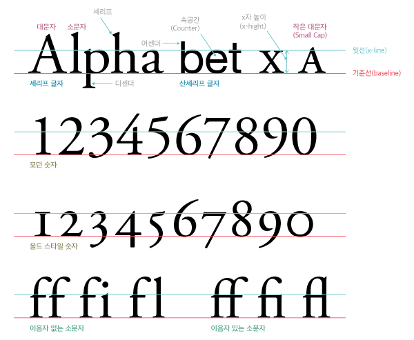

## 그래픽 장치 {#graphics-device}

`ggplot`에 텍스트를 화면에 표현하는 그래픽 장치(Graphics Device, GD)는 5가지가 존재한다.

- `png()`
- `pdf()`
- 스크린 화면 : Windows
- 스크린 화면 : Mac
- 스크린 화면 : Linux

5가지 그래픽 장치는 서로 달라 정확한 텍스트를 화면이나 `png`, `pdf` 파일이나 이미지에 넣는 것은 쉽지 않지만, 다음 팩키지가 그 역할을 수행하고 있다.

- `showtext`
- `extrafont`
- `systemfonts`

나눔고딕 폰트 테스트 중입니다.

```r
library(showtext)

extrafont::fonttable()$FamilyName
```

```
 [1] "KoPubWorldBatang Bold"       "KoPubWorldBatang Light"
 [3] "KoPubWorldBatang Medium"     "KoPubWorldDotum Bold"
 [5] "KoPubWorldDotum Light"       "KoPubWorldDotum Medium"
 [7] "NanumBarunGothic"            "NanumBarunGothic"
 [9] "NanumBarunGothic Light"      "NanumBarunGothic UltraLight"
[11] "NanumBarunpen"               "NanumBarunpen Bold"
[13] "Nanum Brush Script"          "NanumGothic"
[15] "NanumGothic"                 "NanumGothicCoding"
[17] "NanumGothicCoding"           "NanumGothicExtraBold"
[19] "NanumGothic Light"           "NanumMyeongjo"
[21] "NanumMyeongjo"               "NanumMyeongjoExtraBold"
[23] "Nanum Pen Script"            "NanumSquare Bold"
[25] "NanumSquare ExtraBold"       "NanumSquare Light"
[27] "NanumSquare"                 "NanumSquareRound Bold"
[29] "NanumSquareRound ExtraBold"  "NanumSquareRound Light"
[31] "NanumSquareRound Regular"
```

# 2 `font` 운동장

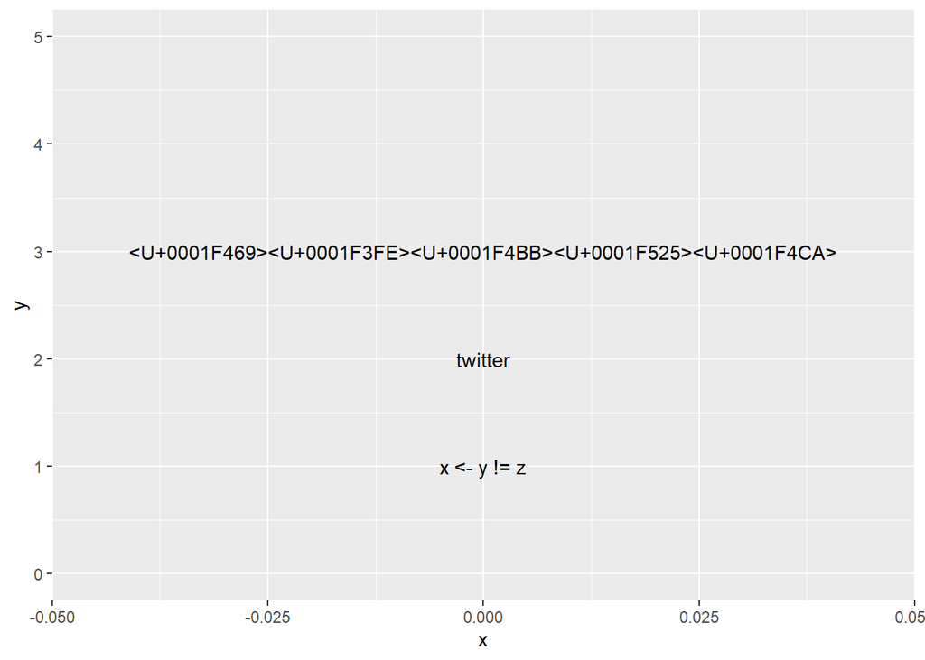

```r
library(tidyverse)
library(ragg)
library(systemfonts)

code <- "x <- y != z"
logo <- "twitter"
fallback_text <- "This is English, 이것은 한국어다. この文は日本語です 🚀"
emojis <- "👩🏾💻🔥📊"

p <- ggplot() +
  geom_text(
    aes(x = 0, y = 1, label = code),
    family = "Fira Code"
  ) +
  geom_text(
    aes(x = 0, y = 2, label = logo),
    family = "Font Awesome 5 brands"
  ) +
  geom_text(
    aes(x = 0, y = 3, label = fallback_text),
    family = "Font Awesome 5 brands"
  ) +
  geom_text(
    aes(x = 0, y = 3, label = emojis),
    family = "Font Awesome 5 brands"
  ) +
  expand_limits(y = c(0, 5))
p
```

# 3 `typeface` vs `font`

`typeface`는 서체로 번역되고 `font`는 글꼴로 번역된다. 하나의 `typeface`에 다수 `font`가 포함될 수 있다. [**팬그램(Pangram)**](https://ko.wikipedia.org/wiki/팬그램)은 ’모든 글자’라는 뜻으로 주어진 모든 문자를 적어도 한 번 이상 사용하여 만든 문장을 뜻한다. 팬그램은 로렘 입숨처럼 글꼴 샘플을 보여주거나 장비를 테스트하는 데 사용된다. 영어 팬그램으로 가장 유명한 ’The quick brown fox jumps over the lazy dog’는 19세기부터 사용되어 왔다.

## 3.1 문서 - R 마크다운

아래 서체(typeface, font family)는 `Noto Sans CJK KR`이나 글꼴(font)은 크기, 굵기, 스타일에 따라 다양하게 텍스트를 표현할 수 있다.

**서체(typeface, `Noto Sans CJK KR`)**

다람쥐 헌 쳇바퀴에 타고파

**글꼴(font)**

다람쥐 헌 쳇바퀴에 타고파

다람쥐 헌 쳇바퀴에 타고파

다람쥐 헌 쳇바퀴에 타고파

다람쥐 헌 쳇바퀴에 타고파

다람쥐 헌 쳇바퀴에 타고파

다람쥐 헌 쳇바퀴에 타고파

R마크다운에서 다양한 서체를 글꼴을 달리하여 표현하는 방식은 `css`를 해당 텍스트에 다음과 같이 적용하는 것이다.

```r
<p style="font-family: Noto Sans CJK KR; font-size:17pt; font-style:italic, font-weight:200">
다람쥐 헌 쳇바퀴에 타고파
</p>
```

## 3.2 그래프 - `ggplot`

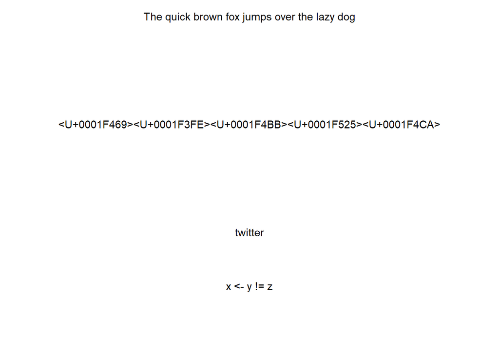

```r
code <- "x <- y != z"
logo <- "twitter"
fallback_text <- "This is English, 이것은 한국어다. この文は日本語です 🚀"
emojis <- "👩🏾💻🔥📊"
korean_text <- "다람쥐 헌 쳇바퀴에 타고파"
english_text <- "The quick brown fox jumps over the lazy dog"

ggplot() +
  geom_text(
    aes(x = 0, y = 1, label = code),
    family = "Fira Code") +
  geom_text(
    aes(x = 0, y = 2, label = logo),
    family = "") +
  geom_text(
    aes(x = 0, y = 3, label = fallback_text),
    family = "") +
  geom_text(
    aes(x = 0, y = 4, label = emojis),
    family = "") +
  geom_text(
    aes(x = 0, y = 5, label = korean_text),
    family = "NanumGothic") +
  geom_text(
    aes(x = 0, y = 6, label = english_text),
    family = "") +
  expand_limits(y = c(0, 5)) +
  theme_void(base_family = 'Open Sans')
```

```r
  # theme(text = element_text(family = 'Open Sans'))
```

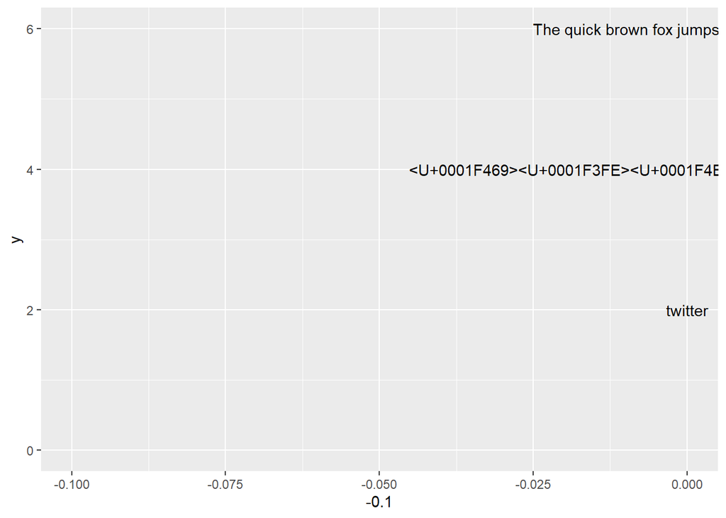

```r
ggplot() +
  geom_text(
    aes(x = -0.1, y = 5, label = korean_text),
    family = "NanumGothic") +
  geom_text(
    aes(x = 0, y = 2, label = logo),
    family = "") +
  geom_text(
    aes(x = 0, y = 3, label = fallback_text),
    family = "") +
  geom_text(
    aes(x = 0, y = 4, label = emojis),
    family = "") +
  geom_text(
    aes(x = 0, y = 5, label = korean_text),
    family = "NanumGothic") +
  geom_text(
    aes(x = 0, y = 6, label = english_text),
    family = "NanumGothic") +
  expand_limits(y = c(0, 5))
```

## 3.3 설치된 글꼴 확인

[`systemfonts`](https://github.com/r-lib/systemfonts) 팩키지를 활용하여 로컬 컴퓨터에서 설치된 글꼴을 확인할 수 있다.

```r
library(systemfonts)

match_font('NanumGothic')
```

```
$path
[1] "C:\\WINDOWS\\Fonts\\NanumGothic.ttf"

$index
[1] 0

$features
NULL
```

```r
system_fonts() %>%
  filter(str_detect(family, "Noto"))
```

```
# A tibble: 9 x 9
  path              index name      family   style weight width italic monospace
  <chr>             <int> <chr>     <chr>    <chr> <ord>  <ord> <lgl>  <lgl>
1 "C:\\Users\\stat~     0 NotoSans~ Noto Sa~ Regu~ normal norm~ FALSE  FALSE
2 "C:\\Users\\stat~     0 NotoSans~ Noto Sa~ Black heavy  norm~ FALSE  FALSE
3 "C:\\Users\\stat~     0 NotoSans~ Noto Sa~ Bold  bold   norm~ FALSE  FALSE
4 "C:\\Users\\stat~     0 NotoSans~ Noto Sa~ Demi~ <NA>   norm~ FALSE  FALSE
5 "C:\\Users\\stat~     0 NotoSans~ Noto Sa~ Light light  norm~ FALSE  FALSE
6 "C:\\Users\\stat~     0 NotoSans~ Noto Sa~ Medi~ medium norm~ FALSE  FALSE
7 "C:\\Users\\stat~     0 NotoSans~ Noto Sa~ Regu~ normal norm~ FALSE  FALSE
8 "C:\\Users\\stat~     0 NotoSans~ Noto Sa~ Thin  <NA>   norm~ FALSE  FALSE
9 "C:\\Users\\stat~     0 NotoSans~ Noto Sa~ Bold  bold   norm~ FALSE  FALSE
```

“다람쥐 헌 쳇바퀴에 타고파” 문장을 글꼴과 굵기를 달리하여 `ggplot`에 시각화해보자.

[figure not shown]

```r
library(extrafont)
# extrafont::font_import(pattern = "NanumBarunGothicBold",  prompt = FALSE)
# extrafont::font_import(pattern = "NanumBarunGothicLight", prompt = FALSE)
loadfonts()

ggplot() +
  geom_text(
    aes(x = -0.1, y = 5, label = korean_text),
    family = "Noto Sans CJK KR", fontface = "plain", size = 7) +
  geom_text(
    aes(x = -0.1, y = 4, label = korean_text),
    family = "Noto Sans CJK KR", fontface = "bold", size = 7) +
  geom_text(
    aes(x = -0.1, y = 3, label = korean_text),
    family = "NanumGothic", fontface = 1.5, size = 7) +
  geom_text(
    aes(x = -0.1, y = 2, label = korean_text),
    family = "NanumGothic", fontface = 2, size = 7) +
  labs(title = korean_text) +
  expand_limits(y = c(1, 5))  +
  # theme(text = element_text(face="bold")) +
  theme_gray(base_family = "Noto Sans CJK KR")
```

[output not shown]

[^1]: [이경 (2012년 12월 03일), “타이포그래피 겉핥기”, spoqa 기술블로그](https://spoqa.github.io/2012/12/03/Typography.html)

데이터 과학자 [이광춘](https://github.com/statkclee/) 저작

*kwangchun.lee.7@gmail.com*